# Major differences in major championship venues

In August 2021, the USGA revealed the organization’s latest set of future sites for its top championships. Senior managing director of championships John Bodenhamer [had this to say](https://www.golfdigest.com/story/usga-oakmont-country-club-us-open-anchor-site-merion-golf-club) about a set of courses that included heavy hitters like Merion and Oakmont:

“We’ve asked players where they want to win their U.S. Open and we know the sites they speak of very highly. The ghosts of the past matter. What has come before these great players … Hogan in 1953 at Oakmont, Nicklaus and Palmer [in 1962], DJ in 2016. All the great moments that are here, that matters. When a man or woman wins, I won where this happened, that’s hugely important.”

One of the marks of a major championship is the prestige of the venue where it is held. The Masters earns the highest television ratings and is the tournament pros most want to win not because of its field, which is the weakest of the four majors. It’s all about the history of Bobby Jones and Augusta National.

Unlike the Masters, USGA tournaments travel around the country to different host sites. The six most important USGA events are aimed at the world’s best professional and amateur players - the U.S. Open (founded in 1895), U.S. Amateur (1895), and Walker Cup (1922) on the men’s side, and the U.S. Women’s Open (1946), U.S. Women’s Amateur (1895), and Curtis Cup (1932) on the women’s side.

All of these competitions have decades of history and the imprimatur of the country’s top golf organization. Bodenhamer is right to point out that both male and female players value winning at the most historic venues. But has the USGA given them the opportunity to do so?

Let’s start with the men’s events, showing year on the x-axis (left is earlier, right is later) and ranking on the y-axis (better rankings are at the top, while lower rankings are at the bottom). Dots appearing in the shaded red area at the bottom were unranked in both lists at the time of the event.

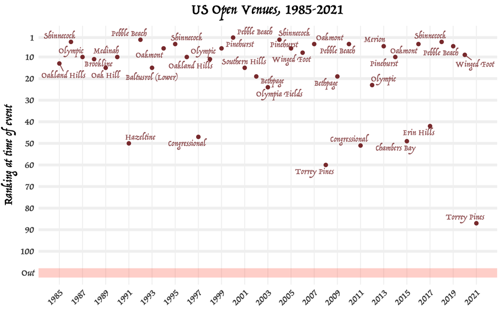

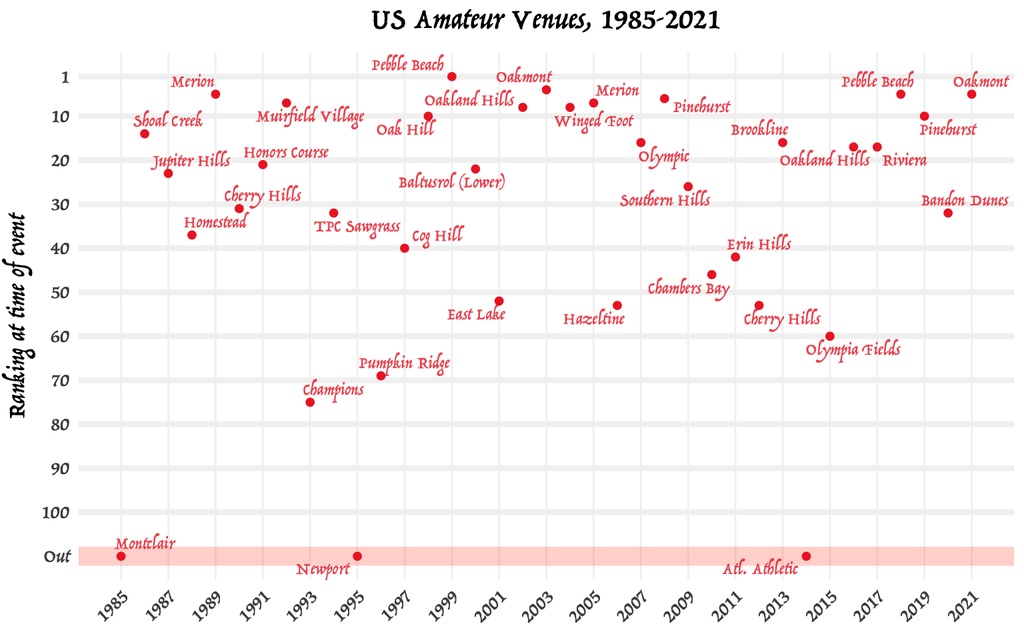

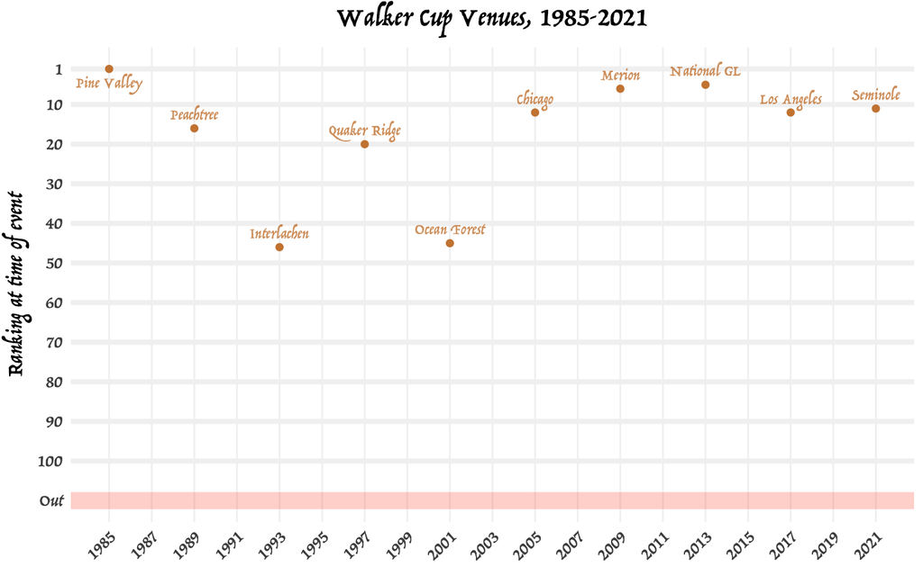

- **US Opens are almost exclusively played at the nation’s top-ranked courses.** Every single US Open has been played at a ranked course, and the vast majority of events since 1983 have been hosted by a course ranked in the top 30 at the time by Golf Digest or Golf Magazine.
- **There is a clear recent trend of the US Open visiting some less heralded venues.** Mike Davis’s tenure as head of the USGA was highlighted by the decision to host US Opens at nontraditional public courses. As a result, the average ranking slipped substantially in the mid-2000s. Torrey Pines, host of the 2008 and 2021 events, is the least-regarded course to host a US Open in the past 30 years, and perhaps ever. Bodenhamer’s recent “don’t call it a rota” rota announcement may mark the end of this experiment.
- **Walker Cup venues match US Opens in prestige and may even overshadow them in exclusivity.** The Walker Cup, hosted quadrenially in the US, is catnip for some of the country’s most exclusive clubs. (The word “club” can be used instead of “course” - Walker Cup has never been played at a single American public venue in its 100-year history.) Pine Valley, National Golf Links of America, Peachtree, and Seminole may not have the viewing space, course length, or member willingness to host a major stroke play event where the organizers will mandate course changes in order to protect par, but they are happy to host a match play tournament for 24 top amateurs and a few hundred spectators.
- **The US Amateur is a notch below the US Open and Walker Cup but still played almost exclusively at ranked courses.** The US Am is a large-scale event requiring two courses and six days of competition to identify a winner among over 300 competitors. As a result, most venues have multiple courses on the premises and those that don’t tend to be in major metropolitan areas with another top-level course nearby. There is a decent amount of overlap between US Open and US Amateur venues at the top levels with the exception of Shinnecock Hills, which hasn’t hosted a US Am since the second playing of the event in 1896.

Now for the women’s tournaments:

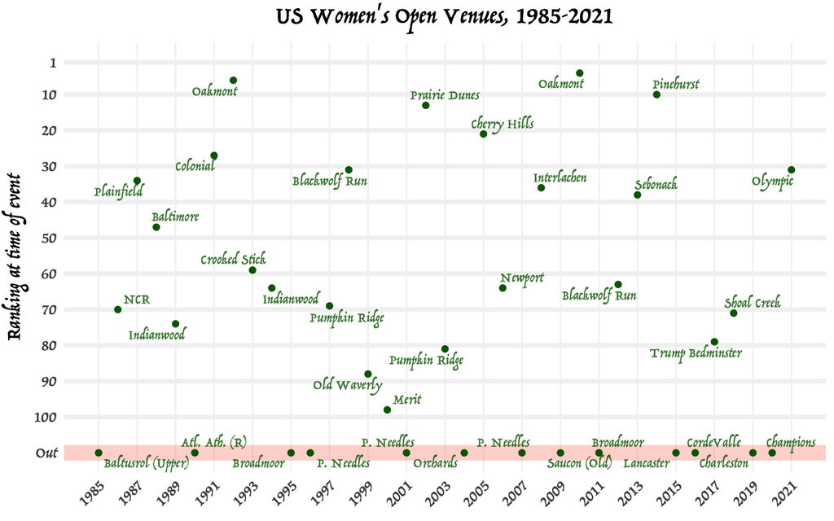

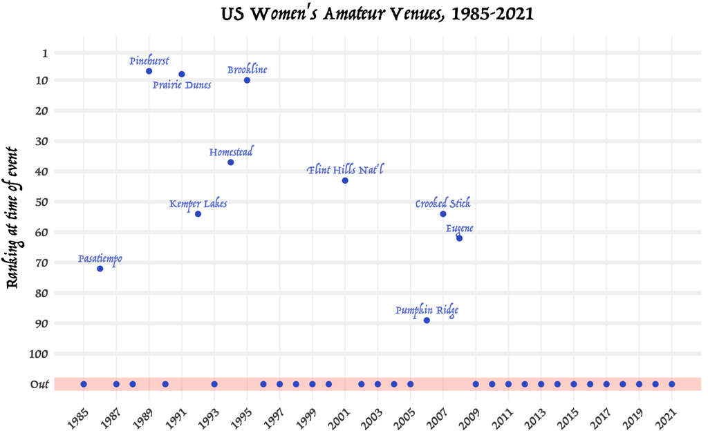

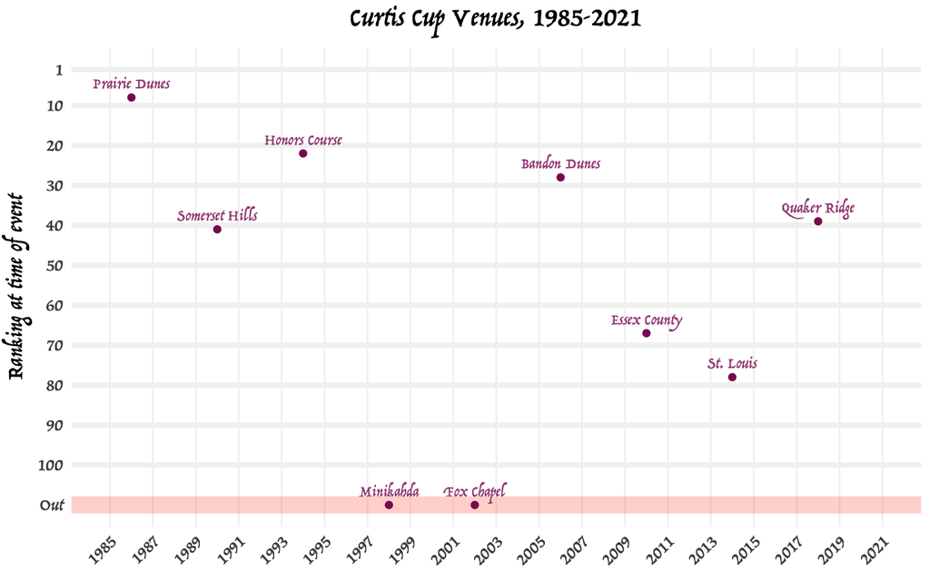

Men vs. women fast facts:

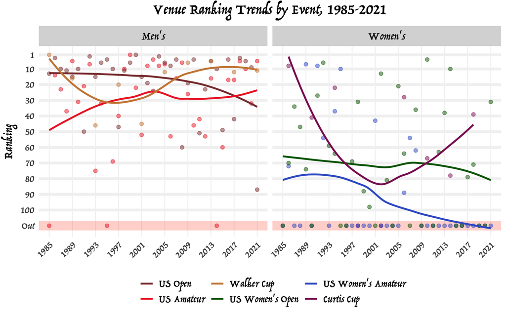